# Introduction to queues

## What are queues

- *Items* (customers, patients, cars) enter a system (check-out, hospital, repair shop) for service.
- They may have to *wait* in-line, in the queue, to be serviced.
- When they finally receive *service*, this also takes time.
- When they are done, they depart the system, this may also take time.
- Queuing time and service time, (and departure time) are often considered together.
- We are interested in quantities such as how many items are in a system at a time \(t\), average time in the system, and the stability of the queue.

## Some terminology and common assumptions

- The *discipline* of a queue refers to how items are serviced: first in first out (FIFO) being a common assumption.
- Usually one or more servers.
- Arrival time to the queue are often assumed to correspond to a renewal process.
- Service times are often assumed to be i.i.d.
- Technical maths tools that are used in analysing queues include finding hidden Markov chains.

## Kendall notation

- A/S/c; three parameters denoting the inter-arrival times, service times, and the number of servers.
- Inter-arrival times and service times are i.i.d. and the queue is by default FIFO.
- M stands for Markov (exponential times)
- M/M/1 or \(M(\lambda)/M(\mu)/1\) refers to a queue with one server, where inter-arrival and service times are exponential (with not necessary the same rate).
- G/G/1 refers to a general (and not necessarily the same) distribution for arrivals and service.

## Code M/M/1

Hidden in an early exercise, we had considered such a queue, with \(\lambda = 1\) and \(\mu = 1.5\). We had code that produced a histogram of the total an item spends in such a system.

```r
inter=rexp(1000, 1)
arr=cumsum(inter)
service = rexp(1000,1.5)

output <- arr[1] + service[1]
for (i in 1:999){
if (arr[i+1] < output[i]){output <- c(output, output[i] + service[i+1])}
if (arr[i+1] > output[i]){output <- c(output, arr[i+1] + service[i+1])}
output
}
```

## continued

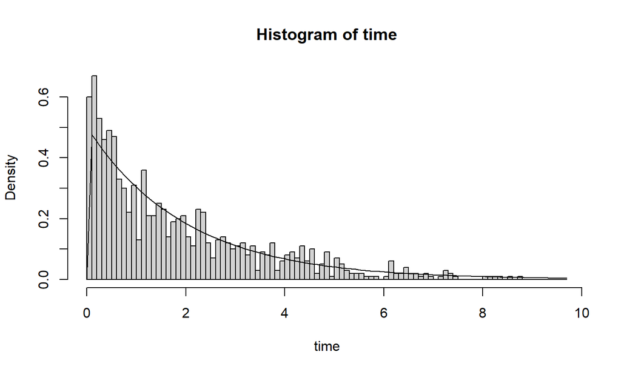

```r
time = output - arr
x = seq(0,max(time)+1, by=0.01)
b = seq(0,max(time)+1, by=0.1)
hist(time, prob=T, breaks=b)
curve(dexp(x,0.5), add=T)
```

## General results

The ratio of the expected service time over expected inter-arrival time is the **traffic intensity**. Let \(Q(t)\) be the number of customers in the system (waiting and being serviced) at time \(t\). We say that \(Q\) is **stable** if the law of \(Q(t)\) converges to a probability distribution as \(t \to \infty\). For a G/G/1 queue, we have:

- If the traffic intensity is strictly less than \(1\), then \(Q\) is stable
- If the traffic intensity is greater than \(1\), then \(Q\) is not stable
- If the traffic intensity is \(1\), then \(Q\) is not stable, provided one of the service time or inter-arrival time is not deterministic.

## Little’s law; \(L = \lambda W\);

Exact version in \([0,T]\): *For a system that is empty at \(0\) and \(T\)*

- \(Q(t)\) = number of items in the system at time \(t\)
- \(\lambda\) = average arrival rate in \([0,T]\)
- \(N\) = the total number of items arriving in \([0,T]\)
- \(L\) = average number of items in the system in \([0,T]\)
- \(W\) =average waiting time of an item in \([0,T]\)
- \(A = \int_0^T Q(t)dt\) area under \(Q\) curve

## Proof

Here *average* is defined so that

- \(L = A/T\)
- \(\lambda = N/T\)
- \(W = A/N\)
- Hence \[L = (A/T) = (A/N) * (N/T) = \lambda W.\]

## Notes

- Little advocates for this version of his law.
- Basically no assumptions required.
- The quantities \(L\), \(\lambda\), and \(W\) are locked-in a relationship like Ohm’s law.
- One quantity can be easily calculated assuming the others can be measured.

## Long-term average version via renewal-reward

- Customers arrive one at a time with the \(n\)th customer spending time \(V_n\)
- There exists a **regeneration time** \(T_1\) that is finite almost surely, so that the queue is empty, and restarts a fresh at this random time, like a stopping time.
- Thus the inter-arrival times of these regeneration times \(X_i = T_i - T_{i-1}\) are i.i.d. and the regeneration times form a renewal process. Take \(T_0 = 0\).
- Each time *cycle* \([T_{i-1}, T_i)\) behaves independently. That is, if \(N_1\) is the number of arrivals in \([T_0, T_1)\) then it is independent of \(N_2\), but identically distributed.

## Standing assumption

- We assume that \(\mathbb{E} N_1 < \infty\), \(\mathbb{E} T_1 < \infty\), and \(\mathbb{E}(N_1 T_1) < \infty\).
- These assumptions did not show up in the previous verison of these slides.

## Continued

- Consider the reward at each cycle to be given by

\[ R_i = \int_{T_{i-1}} ^ {T_{i}} Q(t)dt\]

- Clearly, the \(R_i\) are i.i.d. and \(\mathbb{E} R_1 \leq \mathbb{E}N_1T_1 < \infty\).
- By the law of large numbers for renewal processes it follows that if \(C(t)\) is the total reward up to time \(t\), we have

\[ \lim_{t \to \infty} \frac{1}{t}\int_0 ^t Q(u)du = \lim_{t \to \infty} C(t)/t = \mathbb{E} R_1 / \mathbb{E} T_1=:L\]

## continued

- Similarly, give ourselves the reward \(N_i\) on each cycle, the total of number of items \(N(t)\) satisfies

\[ N(t)/t \to \mathbb{E} N_1 / \mathbb{E} T_1:= \lambda\]

## continued

- Consider another inter-arrival process with inter-arrival times \(N_i\) and give ourselves the reward of the total waiting time in the \(i\)th cycle; in particular, \(S_1 = \sum_{k=1}^ {N_1} V_k\), and the \(S_i\) are i.i.d. with

\[ \mathbb{E}S_1 \leq \mathbb{E} N_1 T_1 < \infty\]

- Again, by the renewal-reward theorem, we have

\[\lim_{n \to \infty} \frac{1}{n}\sum_{k=1} ^n V_k \to \mathbb{E} S_1 / \mathbb{E} N=:W\]

## Little’s theorem \(L = \lambda W\).

Observe that

\[\mathbb{E} S_1= \mathbb{E} \Big( \sum_{k=1} ^{N_1} V_k \Big) = \mathbb{E} \Big( \int_0 ^{T_1} Q(u)du \Big) = \mathbb{E} R_1\] Thus \[ \begin{eqnarray*} L &=& ( \mathbb{E} R_1 /\mathbb{E} T_1 ) \\ &=& ( \mathbb{E} R_1 /\mathbb{E} N_1 )* (\mathbb{E} N_1 / \mathbb{E} T_1) \\ &=& (\mathbb{E} S_1 / \mathbb{E} N_1) * \lambda \\ &=& \lambda W. \end{eqnarray*} \]

## Summary

- We introduced queues and [Kendall’s notation](https://projecteuclid.org/euclid.aoms/1177728975)
- We discussed [Little’s theorem](https://pubsonline.informs.org/doi/abs/10.1287/opre.1110.0940). The link requires UCL VPN.
- See also [Question 4](https://tsoo-math.github.io/ucl/ica3-stat9-sols.html) and [Exercise 3](https://tsoo-math.github.io/ucl/QHW8.1-sols.html)

## Endnotes

- For more information see Grimmett and Stirzker [(2001)](https://zbmath.org/1015.60002).
- For history on queuing see Kingman [(2009)](https://link.springer.com/article/10.1007/s11134-009-9147-4).
- Version: 20 April 2024
- [Rmd Source](https://tsoo-math.github.io/ucl/intro-queues.Rmd)